# STACK responses - analysis of coding

George Kinnear

2022-03-07

## Response summary

There are two issues with the responses that complicate the analysis:

1. STACK offered partial credit for parts b/c/d, and
2. students did not always give a response; these are shown as a score of `NA` rather than a score of 0.

| part | score | n |
| --- | --- | --- |
| a | 0.0 | 128 |
| a | 1.0 | 177 |
| a | NA | 17 |
| b | 0.0 | 111 |
| b | 0.5 | 42 |
| b | 1.0 | 139 |
| b | NA | 30 |
| c | 0.0 | 67 |
| c | 0.5 | 58 |
| c | 1.0 | 166 |

[output cut: 11 more lines]

| Part | Incorrect | Correct | NA | Total |
| --- | --- | --- | --- | --- |
| a | 128 | 177 | 17 | 305 |
| b | 153 | 139 | 30 | 292 |
| c | 125 | 166 | 31 | 291 |
| d | 177 | 113 | 32 | 290 |

| part | Correct | Incorrect | No response | Total |
| --- | --- | --- | --- | --- |
| a | 177 (55%) | 128 (40%) | 17 (5%) | 322 (100%) |
| b | 139 (43%) | 153 (48%) | 30 (9%) | 322 (100%) |
| c | 166 (52%) | 125 (39%) | 31 (10%) | 322 (100%) |
| d | 113 (35%) | 177 (55%) | 32 (10%) | 322 (100%) |

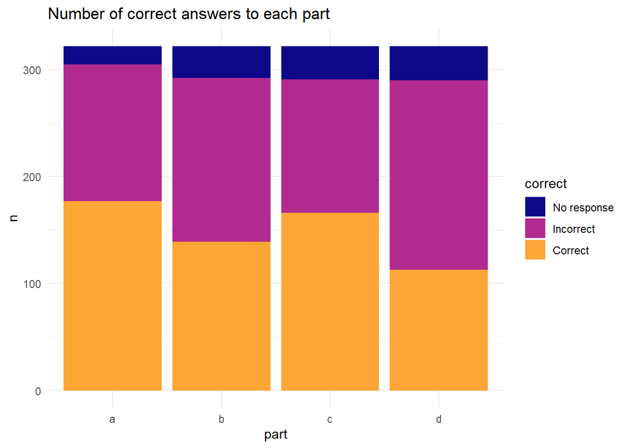

## Response details

(Here, all “null” responses are discarded rather than being counted as incorrect.)

Looking in more detail at the specific questions:

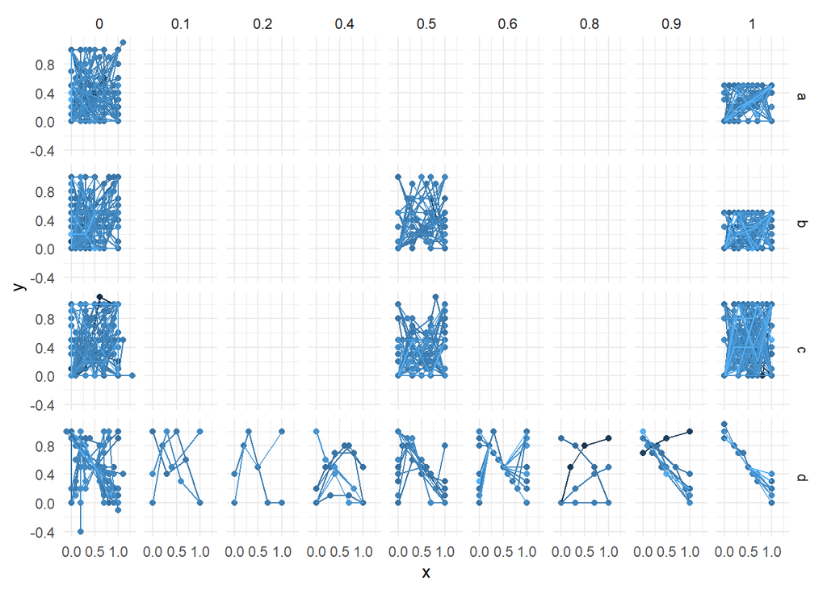

## Check for specific issues in answers

| part | score | example_type | nature_of_mistake | n |
| --- | --- | --- | --- | --- |
| a | 0.0 | not a function |  | 5 |
| a | 0.0 | not a function | domain has gaps | 10 |
| a | 0.0 | not a function | domain has gaps; image is [1/2,1] | 6 |
| a | 0.0 | not a function | domain has gaps; surjective but should not be | 6 |
| a | 0.0 | not a function | domain is [0,1/2] | 4 |
| a | 0.0 | not a function | domain is [0,1/2]; surjective but should not be | 1 |
| a | 0.0 | not a function | image is [1/2,1] | 1 |
| a | 0.0 | not a function | surjective but should not be | 9 |
| a | 0.0 | piecewise linear |  | 20 |
| a | 0.0 | piecewise linear | domain exceeds [0,1]; image goes beyond [0,1] | 1 |
| a | 0.0 | piecewise linear | domain has gaps | 15 |
| a | 0.0 | piecewise linear | domain is [0,1/2] | 12 |
| a | 0.0 | piecewise linear | domain is [0,1/2]; surjective but should not be | 4 |
| a | 0.0 | piecewise linear | image is [1/2,1] | 2 |
| a | 0.0 | piecewise linear | No response | 11 |
| a | 0.0 | piecewise linear | surjective but should not be | 21 |
| a | 1.0 | not a function |  | 7 |
| a | 1.0 | piecewise linear |  | 170 |
| b | 0.0 | not a function |  | 15 |
| b | 0.0 | not a function | domain has gaps | 5 |
| b | 0.0 | not a function | domain has gaps; image other | 6 |
| b | 0.0 | not a function | domain has gaps; image other; injective but should not be | 1 |
| b | 0.0 | not a function | domain has gaps; image too large | 2 |
| b | 0.0 | not a function | domain has gaps; image too large; injective but should not be | 3 |
| b | 0.0 | not a function | domain has gaps; image too small | 1 |
| b | 0.0 | not a function | domain is [0,1/2] | 4 |
| b | 0.0 | not a function | domain is [0,1/2]; image other | 1 |
| b | 0.0 | not a function | domain is [0,1/2]; image too large | 1 |
| b | 0.0 | not a function | domain is [0,1/2]; image too small | 1 |
| b | 0.0 | not a function | image other | 3 |

[output cut: 81 more lines]

### (a) image $[0,\frac12]$

| score | example_type | nature_of_mistake | n |
| --- | --- | --- | --- |
| 1 | not a function |  | 7 |
| 1 | piecewise linear |  | 170 |
| 0 | not a function | domain has gaps | 10 |
| 0 | not a function | surjective but should not be | 9 |
| 0 | not a function | domain has gaps; image is [1/2,1] | 6 |
| 0 | not a function | domain has gaps; surjective but should not be | 6 |
| 0 | not a function |  | 5 |
| 0 | not a function | domain is [0,1/2] | 4 |
| 0 | not a function | domain is [0,1/2]; surjective but should not be | 1 |
| 0 | not a function | image is [1/2,1] | 1 |
| 0 | piecewise linear | surjective but should not be | 21 |
| 0 | piecewise linear |  | 20 |
| 0 | piecewise linear | domain has gaps | 15 |
| 0 | piecewise linear | domain is [0,1/2] | 12 |
| 0 | piecewise linear | No response | 11 |
| 0 | piecewise linear | domain is [0,1/2]; surjective but should not be | 4 |
| 0 | piecewise linear | image is [1/2,1] | 2 |
| 0 | piecewise linear | domain exceeds [0,1]; image goes beyond [0,1] | 1 |

#### Correct answers

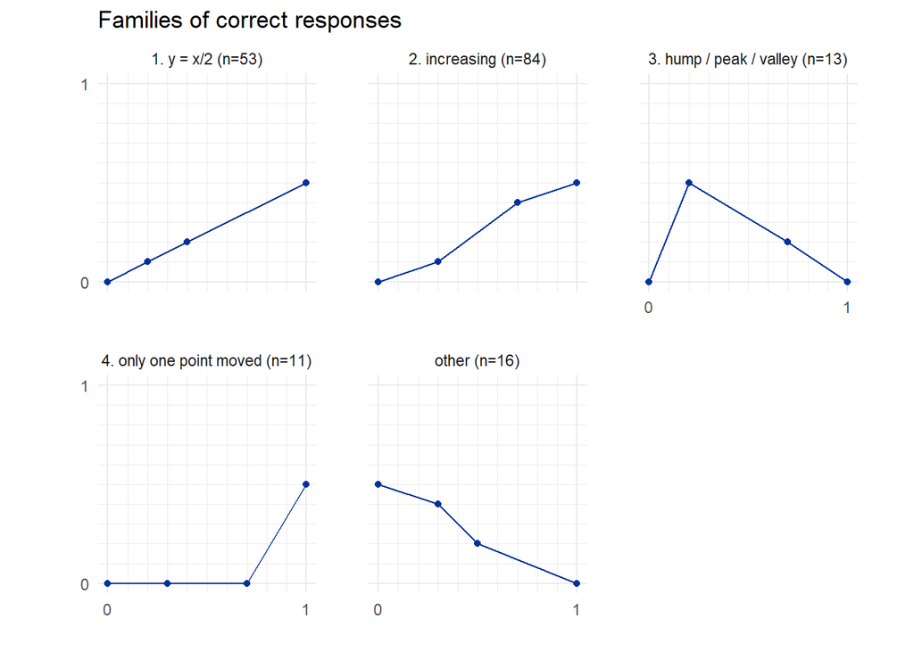

```
## Saving 18 x 12.7 cm image
```

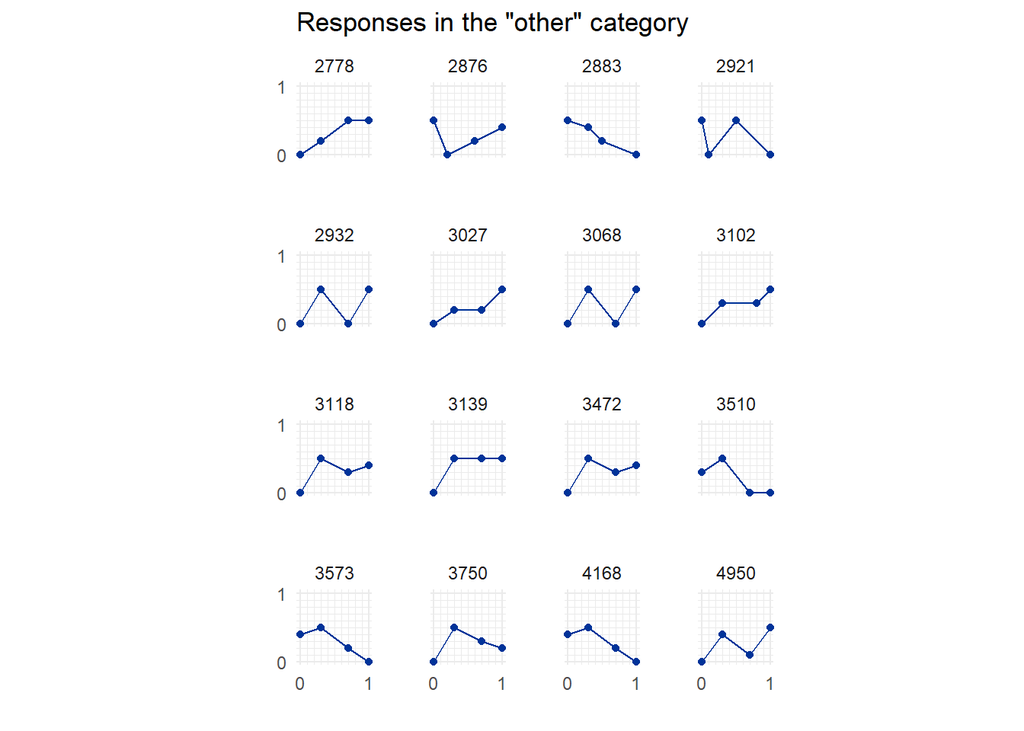

How often did students realise they could move the points horizontally?

| part_a_type | x1 | x2 | x3 | x4 | n |
| --- | --- | --- | --- | --- | --- |
| 1. y = x/2 | 0 | 0.0 | 1.0 | 1 | 2 |
| 1. y = x/2 | 0 | 0.2 | 0.4 | 1 | 4 |
| 1. y = x/2 | 0 | 0.2 | 0.6 | 1 | 18 |
| 1. y = x/2 | 0 | 0.2 | 0.8 | 1 | 2 |
| 1. y = x/2 | 0 | 0.4 | 0.6 | 1 | 8 |
| 1. y = x/2 | 0 | 0.4 | 0.8 | 1 | 16 |
| 1. y = x/2 | 0 | 1.0 | 1.0 | 1 | 2 |
| 1. y = x/2 | 1 | 1.0 | 0.0 | 0 | 1 |
| 2. increasing | 0 | 0.1 | 0.3 | 1 | 4 |
| 2. increasing | 0 | 0.1 | 0.4 | 1 | 1 |

[output cut: 25 more lines]

Most of the “increasing” examples (64 of the 84) used the default x-coordinates.

#### Not a function

Several students gave responses with vertical segments.

Apparent among these are several students joining the points (0,1) and (0,1/2), perhaps confusing the interval notation in the question for coordinates of points?

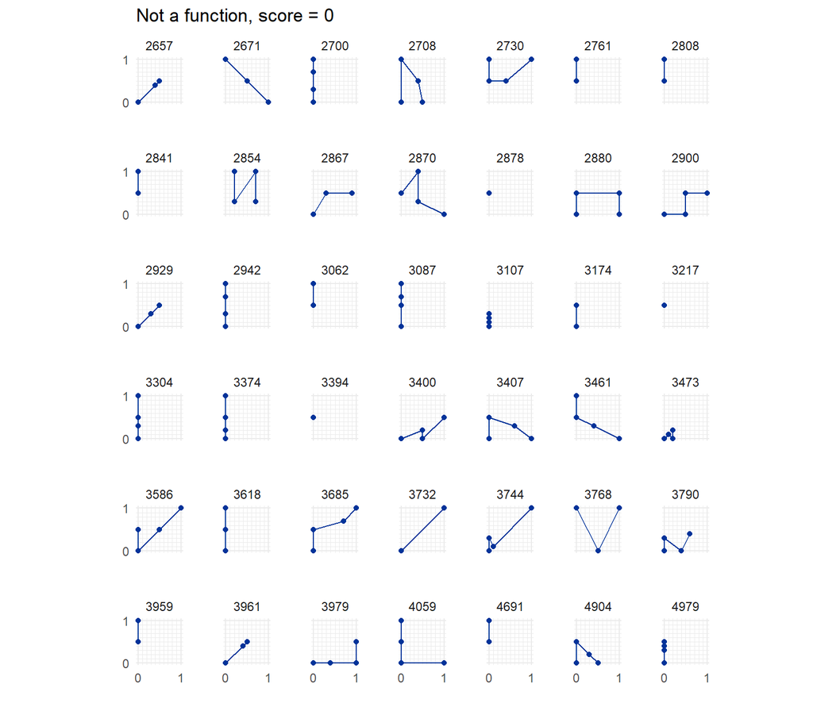

Some of these responses are close to correct, in the sense that minor perturbation of one of the points would make a vertical segment merely very steep, and the function would have the required properties (e.g. `userid` 2900, 3400, 3407).

There were a few students who made some of the points overlap, but ignoring the duplicates, the resulting graph is correct:

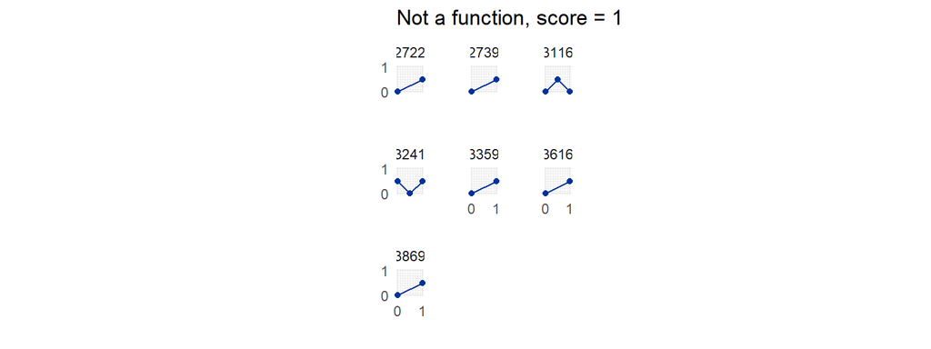

#### Piecewise linear

Among students who correctly plotted a piecewise linear function, there were a few common mistakes.

##### 1. Surjective but should not be

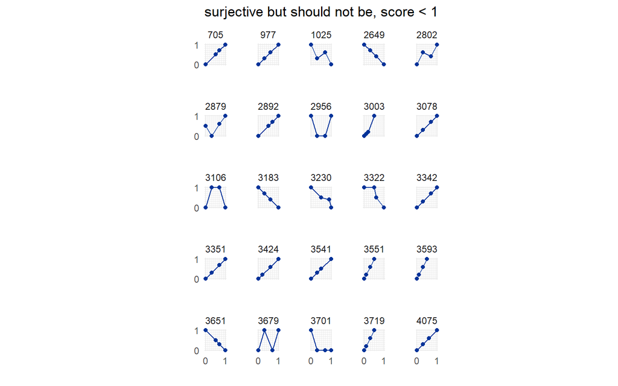

The rest seem to just be ignoring the condition on the image.

##### 2. Confusing domain and image?

Another other common issue was for students to give an example with domain $[0,\frac12]$:

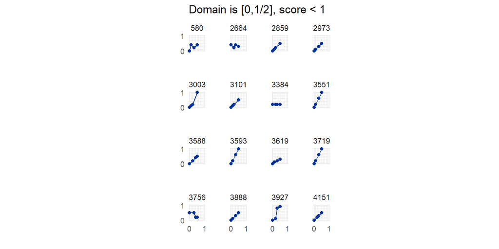

In many of these examples, the image is also $[0,\frac12]$ (e.g. `userid` 4151).

##### 3. Gaps in the domain

Many students used some other subset of $[0,1]$ as the domain, only sometimes with the correct image:

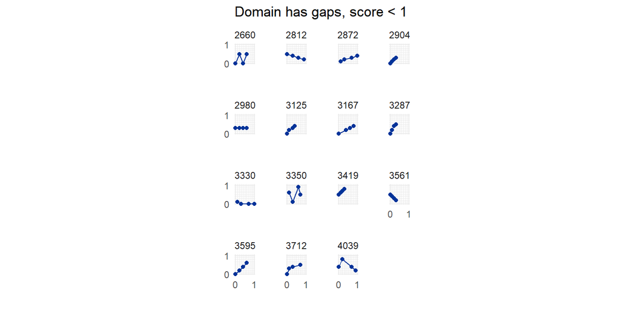

##### 4. Miscellaneous

Finally, there were several students giving responses that were incorrect, but did not fit any of the previously defined categories.

There are perhaps two identifiable “families” among these:

1. constant functions (e.g. `userid` 2741)
2. almost correct answers, perhaps let down by poor scale reading? (e.g. `userid` 2695, where the highest values are close to, but just below, 0.5; or `userid` 3281 which overshoots 0.5 at the right endpoint.)

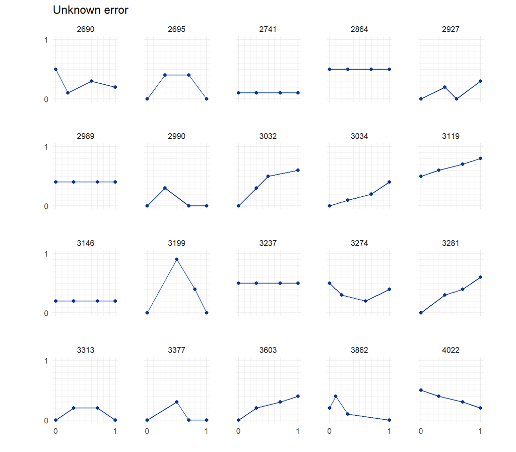

### (b) image $[0,\frac12]$ and not injective

| score | example_type | nature_of_mistake | n |
| --- | --- | --- | --- |
| 1.0 | piecewise linear |  | 139 |
| 0.5 | piecewise linear | image too large | 17 |
| 0.5 | piecewise linear | image too small | 10 |
| 0.5 | piecewise linear |  | 7 |
| 0.5 | piecewise linear | injective but should not be | 6 |
| 0.5 | piecewise linear | image other | 2 |
| 0.0 | not a function |  | 15 |
| 0.0 | not a function | domain has gaps; image other | 6 |
| 0.0 | not a function | image too large | 6 |
| 0.0 | not a function | domain has gaps | 5 |
| 0.0 | not a function | domain is [0,1/2] | 4 |
| 0.0 | not a function | domain has gaps; image too large; injective but should not be | 3 |
| 0.0 | not a function | image other | 3 |
| 0.0 | not a function | domain has gaps; image too large | 2 |
| 0.0 | not a function | image too large; injective but should not be | 2 |
| 0.0 | not a function | injective but should not be | 2 |
| 0.0 | not a function | domain has gaps; image other; injective but should not be | 1 |
| 0.0 | not a function | domain has gaps; image too small | 1 |
| 0.0 | not a function | domain is [0,1/2]; image other | 1 |
| 0.0 | not a function | domain is [0,1/2]; image too large | 1 |
| 0.0 | not a function | domain is [0,1/2]; image too small | 1 |
| 0.0 | not a function | image too small | 1 |
| 0.0 | piecewise linear | image too large; injective but should not be | 9 |
| 0.0 | piecewise linear |  | 6 |
| 0.0 | piecewise linear | domain is [0,1/2] | 6 |
| 0.0 | piecewise linear | domain is [0,1/2]; image too large | 6 |
| 0.0 | piecewise linear | domain has gaps; image too large; injective but should not be | 4 |
| 0.0 | piecewise linear | domain has gaps; image too small | 4 |
| 0.0 | piecewise linear | image too small | 4 |
| 0.0 | piecewise linear | domain has gaps | 3 |
| 0.0 | piecewise linear | domain has gaps; image too large | 3 |
| 0.0 | piecewise linear | domain has gaps; image too small; injective but should not be | 3 |
| 0.0 | piecewise linear | domain has gaps; image other | 2 |
| 0.0 | piecewise linear | domain has gaps; injective but should not be | 2 |
| 0.0 | piecewise linear | domain is [0,1/2]; image too small | 2 |
| 0.0 | piecewise linear | domain is [0,1/2]; image too small; injective but should not be | 1 |
| 0.0 | piecewise linear | injective but should not be | 1 |
| 0.0 | piecewise linear | No response; image too small | 1 |

#### Correct answers

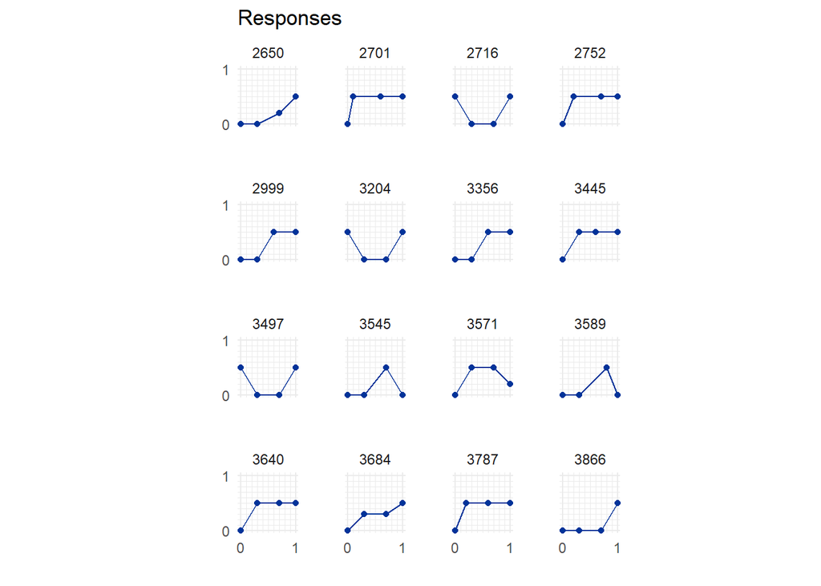

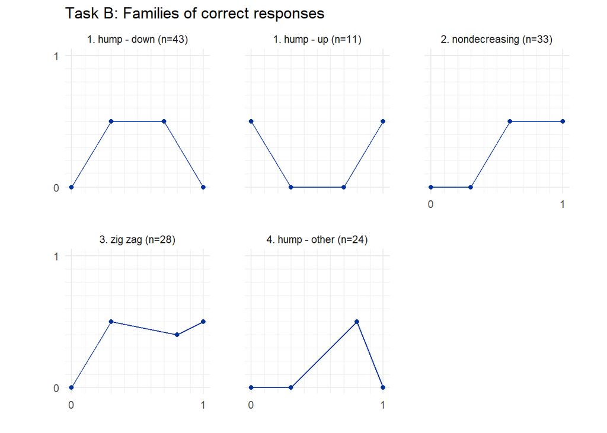

```
## Saving 18 x 12.7 cm image
```

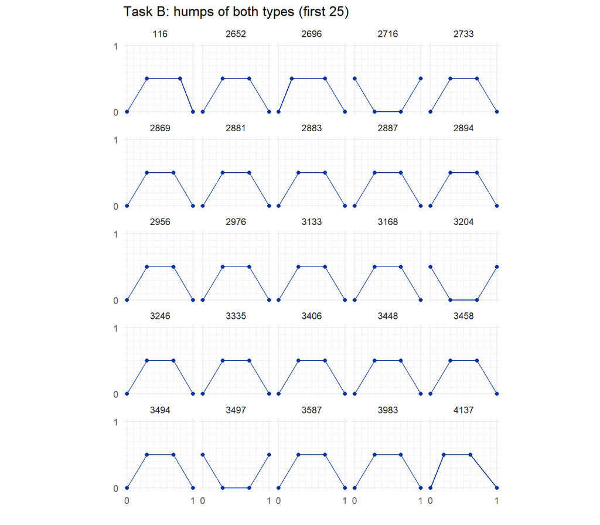

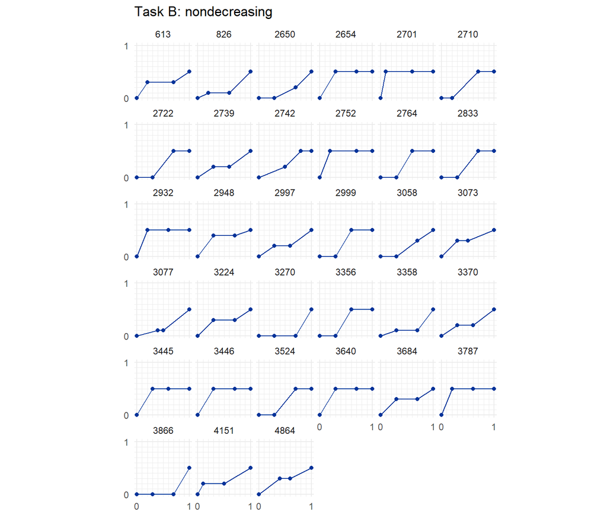

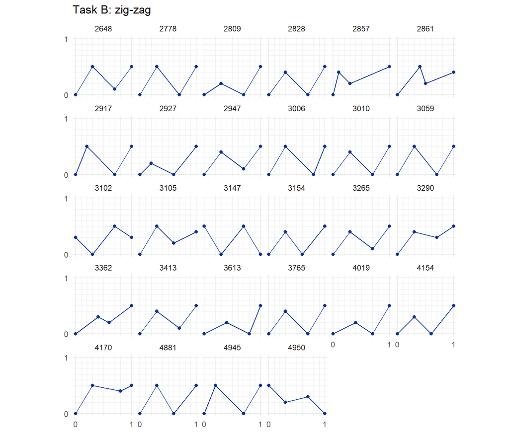

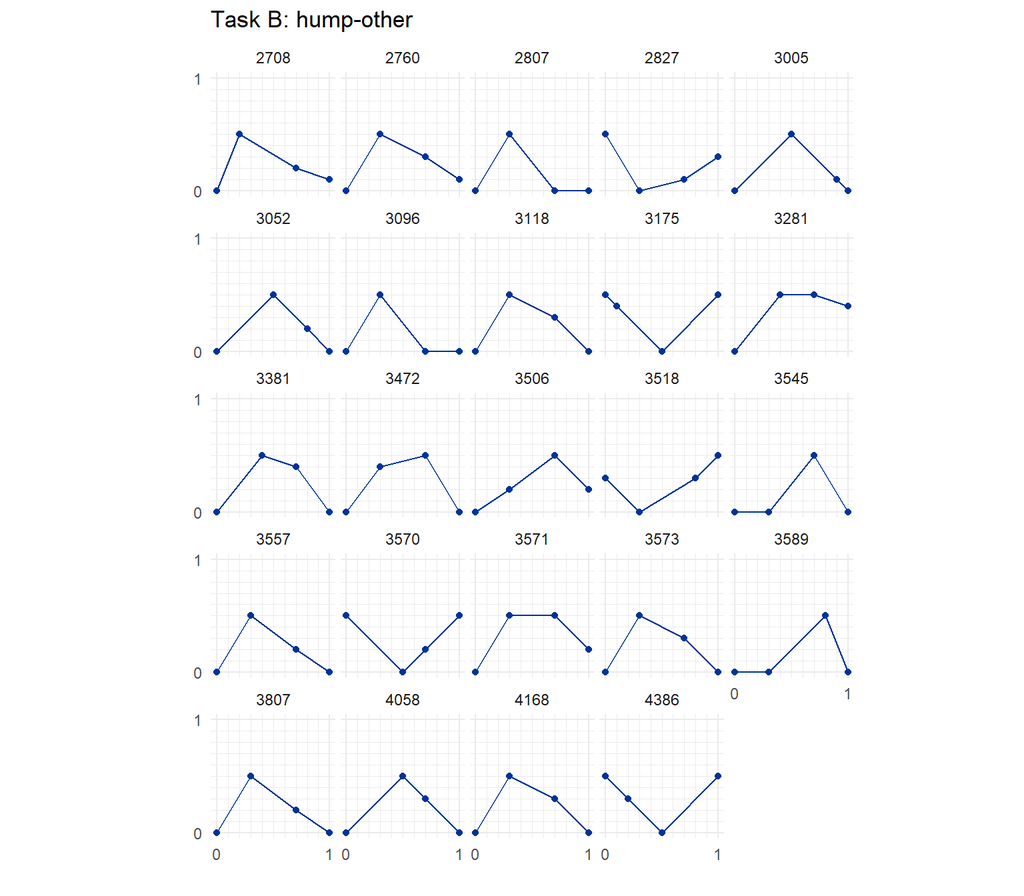

#### Not a function

Within the examples that are “not a function”, some of them had unidentified mistakes. This is either because they use vertical segments, or because two points have been dragged to coincide.

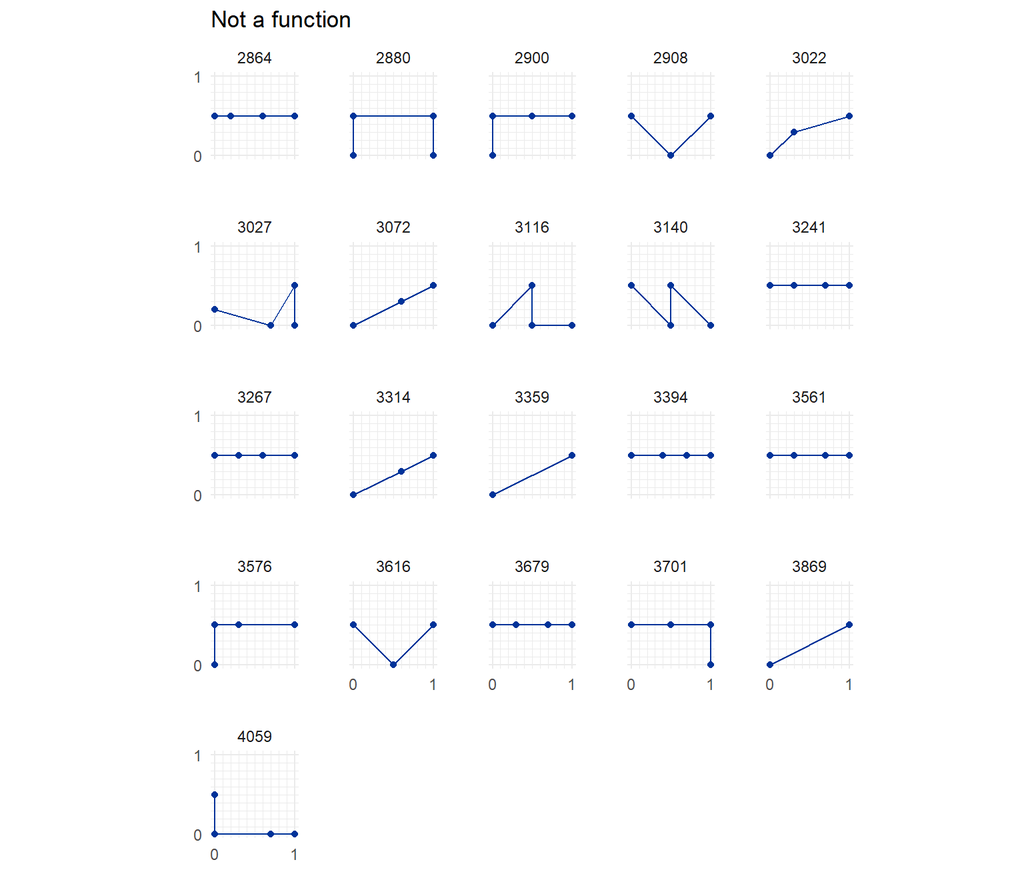

The remaining “not a function” responses are quite varied:

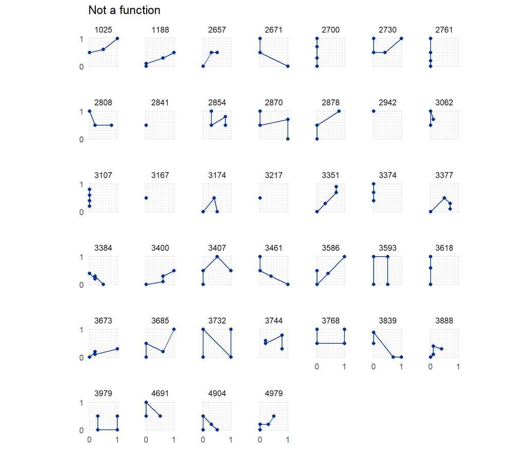

#### Partially correct

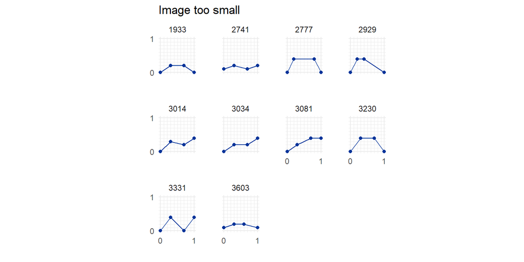

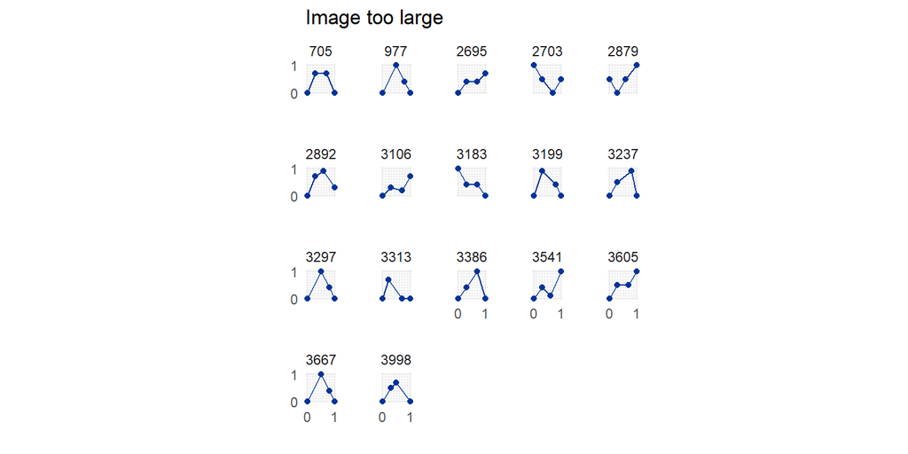

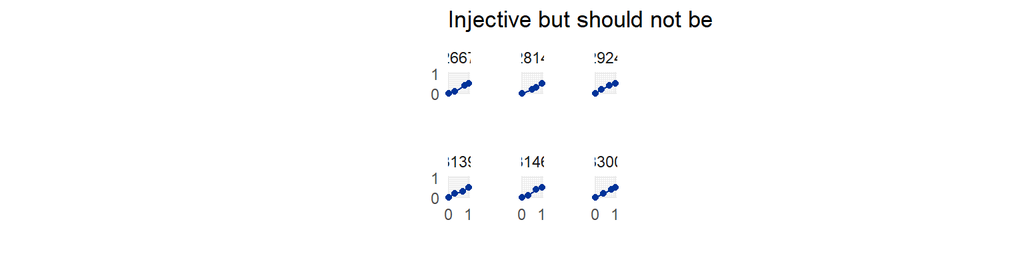

#### Incorrect

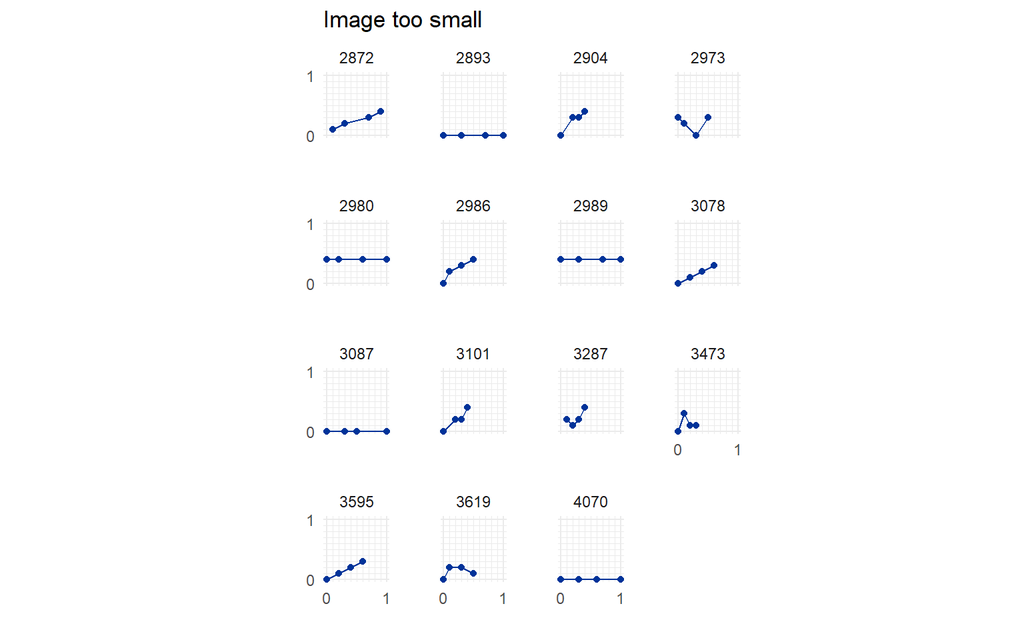

Several of those are horizontal lines.

| mistake | n |
| --- | --- |
| both | 41 |
| domain | 20 |
| image | 55 |
| none | 152 |
| other | 24 |

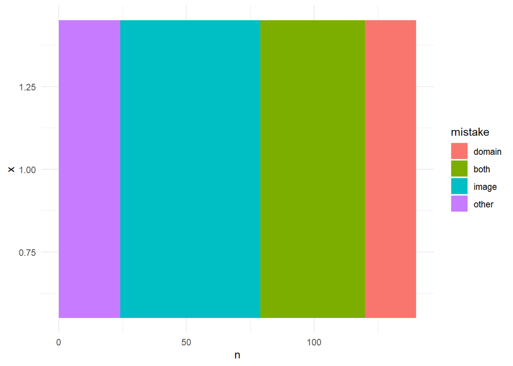

| mistake | nature_of_mistake_domain | nature_of_mistake_image | n |
| --- | --- | --- | --- |
| both | domain has gaps | image other | 9 |
| both | domain has gaps | image too large | 12 |
| both | domain has gaps | image too small | 8 |
| both | domain is [0,1/2] | image other | 1 |
| both | domain is [0,1/2] | image too large | 7 |
| both | domain is [0,1/2] | image too small | 4 |
| domain | domain has gaps | NA | 10 |
| domain | domain is [0,1/2] | NA | 10 |
| image | NA | image other | 5 |
| image | NA | image too large | 34 |

[output cut: 3 more lines]

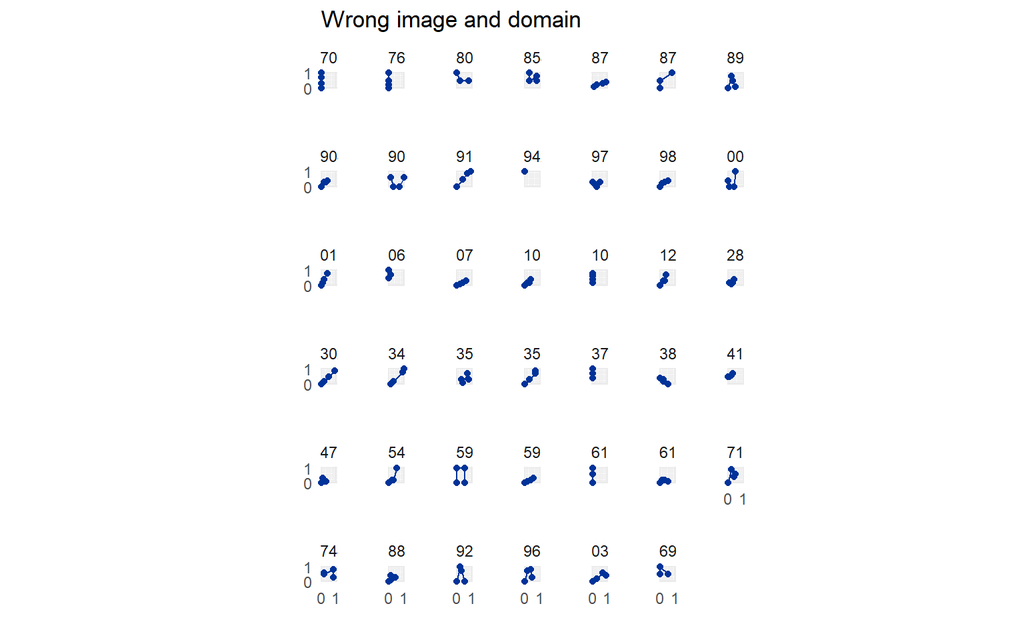

Just the point (0, 1/2) - one student does this for both (a) and (b); there are two other students doing it for (a), and two separate students for (b).

| part | response | score | prt | state | fraction | userid | ans_nums | x1 | y1 | x2 | y2 | x3 | y3 | x4 | y4 | image_min | image_max | domain_min | domain_max | has_repeated_pt | example_type | null_response | nature_of_mistake_domain | nature_of_mistake_image | nature_of_mistake_other | nature_of_mistake |
| --- | --- | --- | --- | --- | --- | --- | --- | --- | --- | --- | --- | --- | --- | --- | --- | --- | --- | --- | --- | --- | --- | --- | --- | --- | --- | --- |
| a | [[0.0,0.5],[0.0,0.5],[0.0,0.5],[0.0,0.5]] | 0 | ATLogic_True. \| prt1-1-T \| (ATList_wrongentries 2). \| prt1-2-F | gradedwrong | 0 | 2878 | 0.0,0.5,0.0,0.5,0.0,0.5,0.0,0.5 | 0 | 0.5 | 0 | 0.5 | 0 | 0.5 | 0 | 0.5 | 0.5 | 0.5 | 0 | 0 | TRUE | not a function | NA | domain has gaps | NA | NA | domain has gaps |
| a | [[0.0,0.5],[0.0,0.5],[0.0,0.5],[0.0,0.5]] | 0 | ATLogic_True. \| prt1-1-T \| (ATList_wrongentries 2). \| prt1-2-F | gradedwrong | 0 | 3394 | 0.0,0.5,0.0,0.5,0.0,0.5,0.0,0.5 | 0 | 0.5 | 0 | 0.5 | 0 | 0.5 | 0 | 0.5 | 0.5 | 0.5 | 0 | 0 | TRUE | not a function | NA | domain has gaps | NA | NA | domain has gaps |
| a | [[0.0,0.5],[0.0,0.5],[0.0,0.5],[0.0,0.5]] | 0 | ATLogic_True. \| prt1-1-T \| (ATList_wrongentries 2). \| prt1-2-F | gradedwrong | 0 | 3217 | 0.0,0.5,0.0,0.5,0.0,0.5,0.0,0.5 | 0 | 0.5 | 0 | 0.5 | 0 | 0.5 | 0 | 0.5 | 0.5 | 0.5 | 0 | 0 | TRUE | not a function | NA | domain has gaps | NA | NA | domain has gaps |
| b | [[0.0,0.5],[0.0,0.5],[0.0,0.5],[0.0,0.5]] | 0 | ATLogic_True. \| prt1-1-T \| (ATList_wrongentries 2). \| prt1-2-F | gradedwrong | 0 | 3167 | 0.0,0.5,0.0,0.5,0.0,0.5,0.0,0.5 | 0 | 0.5 | 0 | 0.5 | 0 | 0.5 | 0 | 0.5 | 0.5 | 0.5 | 0 | 0 | TRUE | not a function | NA | domain has gaps | NA | NA | domain has gaps |
| b | [[0.0,0.5],[0.0,0.5],[0.0,0.5],[0.0,0.5]] | 0 | ATLogic_True. \| prt1-1-T \| (ATList_wrongentries 2). \| prt1-2-F | gradedwrong | 0 | 2841 | 0.0,0.5,0.0,0.5,0.0,0.5,0.0,0.5 | 0 | 0.5 | 0 | 0.5 | 0 | 0.5 | 0 | 0.5 | 0.5 | 0.5 | 0 | 0 | TRUE | not a function | NA | domain has gaps | NA | NA | domain has gaps |
| b | [[0.0,0.5],[0.0,0.5],[0.0,0.5],[0.0,0.5]] | 0 | ATLogic_True. \| prt1-1-T \| (ATList_wrongentries 2). \| prt1-2-F | gradedwrong | 0 | 3217 | 0.0,0.5,0.0,0.5,0.0,0.5,0.0,0.5 | 0 | 0.5 | 0 | 0.5 | 0 | 0.5 | 0 | 0.5 | 0.5 | 0.5 | 0 | 0 | TRUE | not a function | NA | domain has gaps | NA | NA | domain has gaps |

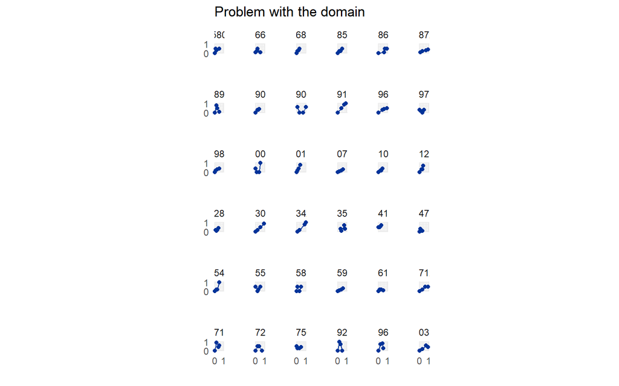

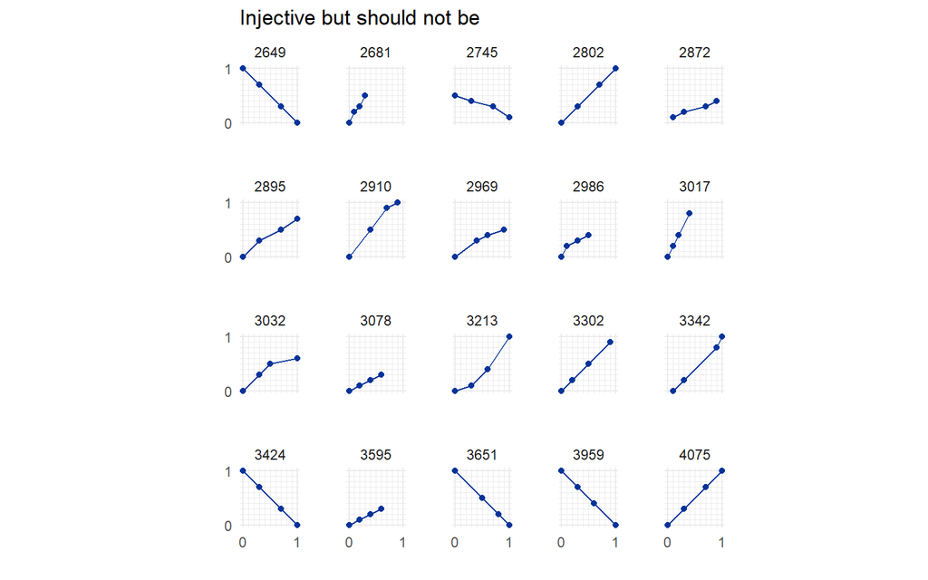

### (c) surjective and not injective

| score | example_type | nature_of_mistake | n |
| --- | --- | --- | --- |
| 1.0 | piecewise linear |  | 166 |
| 0.5 | piecewise linear | image is [0,1/2] | 22 |
| 0.5 | piecewise linear | image too small | 18 |
| 0.5 | piecewise linear | injective but should not be | 17 |
| 0.5 | piecewise linear | image goes beyond [0,1] | 1 |
| 0.0 | not a function |  | 12 |
| 0.0 | not a function | domain has gaps; image too small | 7 |
| 0.0 | not a function | image too small | 5 |
| 0.0 | not a function | injective but should not be | 4 |
| 0.0 | not a function | domain has gaps | 3 |
| 0.0 | not a function | domain is [0,1/2]; image too small | 3 |
| 0.0 | not a function | image is [0,1/2] | 2 |
| 0.0 | not a function | domain exceeds [0,1] | 1 |
| 0.0 | not a function | domain has gaps; injective but should not be | 1 |
| 0.0 | not a function | image is [0,1/2]; injective but should not be | 1 |
| 0.0 | not a function | image too small; injective but should not be | 1 |
| 0.0 | piecewise linear | domain has gaps; image too small | 4 |
| 0.0 | piecewise linear | domain has gaps; image too small; injective but should not be | 4 |
| 0.0 | piecewise linear | domain has gaps | 3 |
| 0.0 | piecewise linear | image too small | 3 |
| 0.0 | piecewise linear | image too small; injective but should not be | 3 |
| 0.0 | piecewise linear | No response; image too small | 2 |
| 0.0 | piecewise linear |  | 1 |
| 0.0 | piecewise linear | domain exceeds [0,1] | 1 |
| 0.0 | piecewise linear | domain has gaps; image goes beyond [0,1] | 1 |
| 0.0 | piecewise linear | domain has gaps; image is [0,1/2] | 1 |
| 0.0 | piecewise linear | domain has gaps; injective but should not be | 1 |
| 0.0 | piecewise linear | domain is [0,1/2] | 1 |
| 0.0 | piecewise linear | image is [0,1/2] | 1 |
| 0.0 | piecewise linear | image is [0,1/2]; injective but should not be | 1 |

#### Correct answers

To get a feel for the range of responses, we first analyse based on the slopes of the three segments:

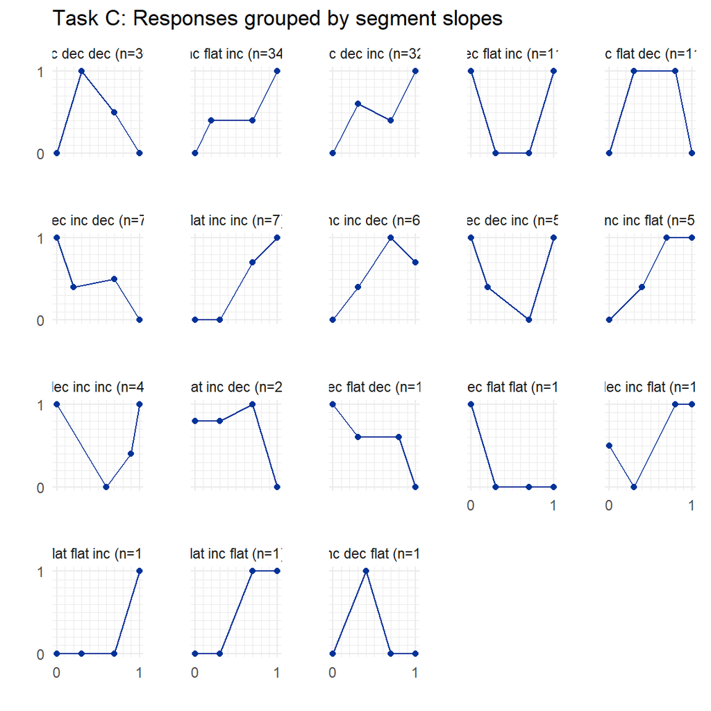

| part_c_type | n |
| --- | --- |
| 1. nondecreasing | 48 |
| 1. nonincreasing | 2 |
| 2. hump (n) | 11 |
| 2. hump (u) | 11 |
| 2. peak | 42 |
| 2. valley | 9 |
| 3. zig zag (dec) | 7 |
| 3. zig zag (inc) | 32 |
| other | 4 |

| incdec_type | n |
| --- | --- |
| decreasing somewhere | 118 |
| nondecreasing | 48 |

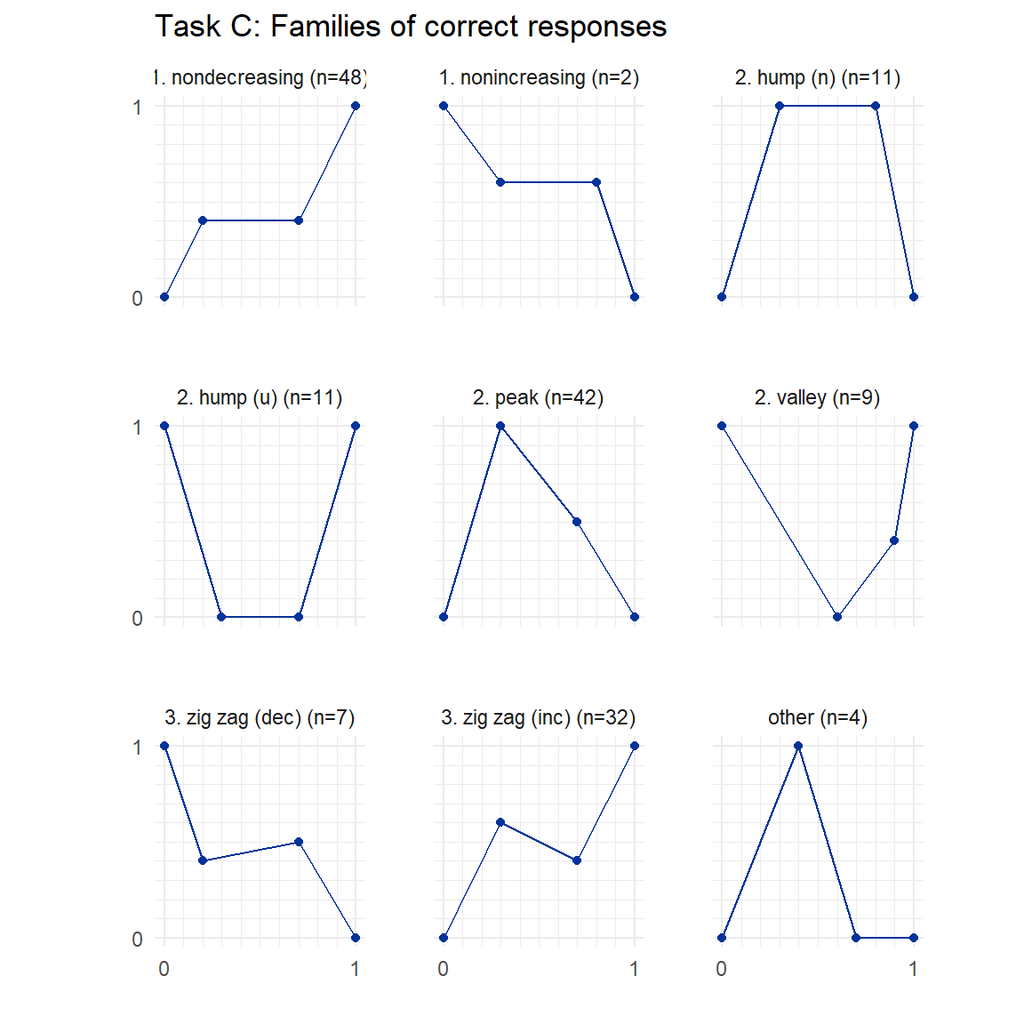

```
## Saving 18 x 15.2 cm image
```

Another way to look at it - answers are only correct if the function is non-injective, which is achieved either with a flat segment, or a change between increasing and decreasing (or both features).

| feature_analysis | n |
| --- | --- |
| both | 26 |
| monotone flat | 50 |
| no flat | 90 |

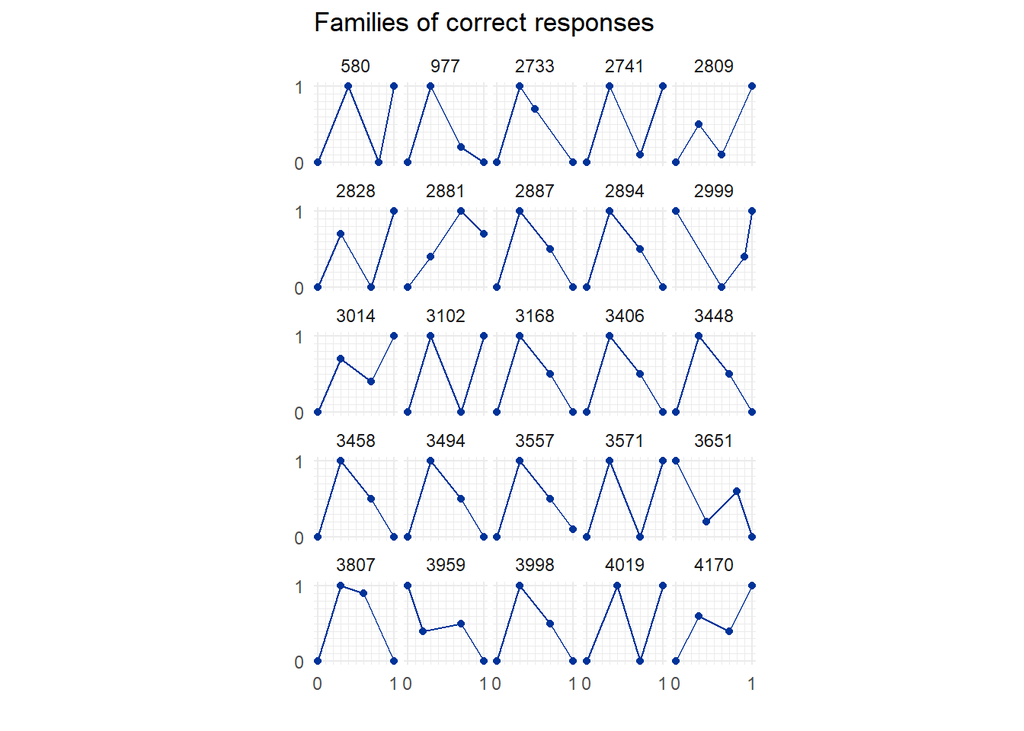

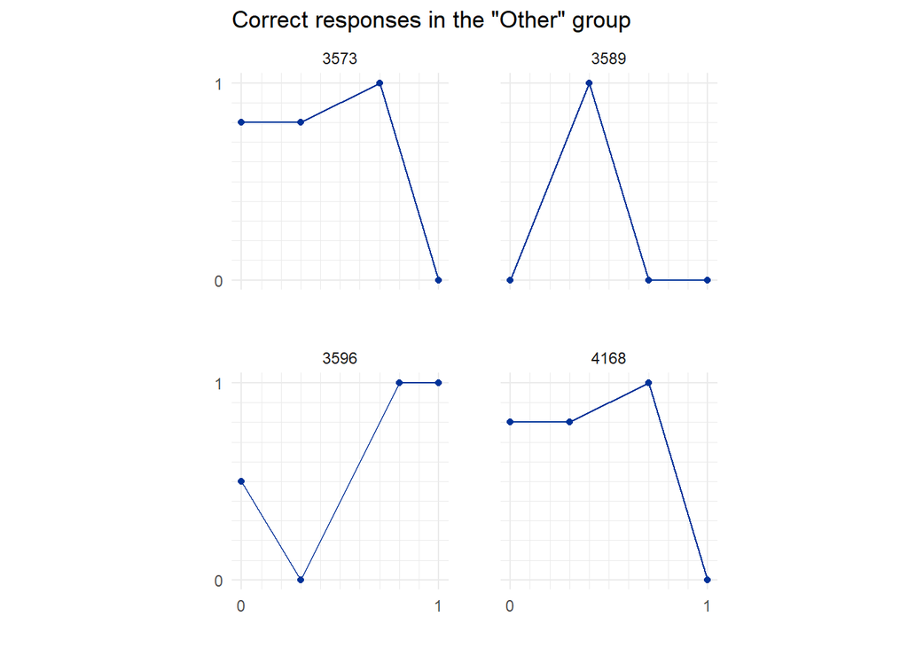

#### Not a function

Most of those with an unidentified error had introduced vertical segments:

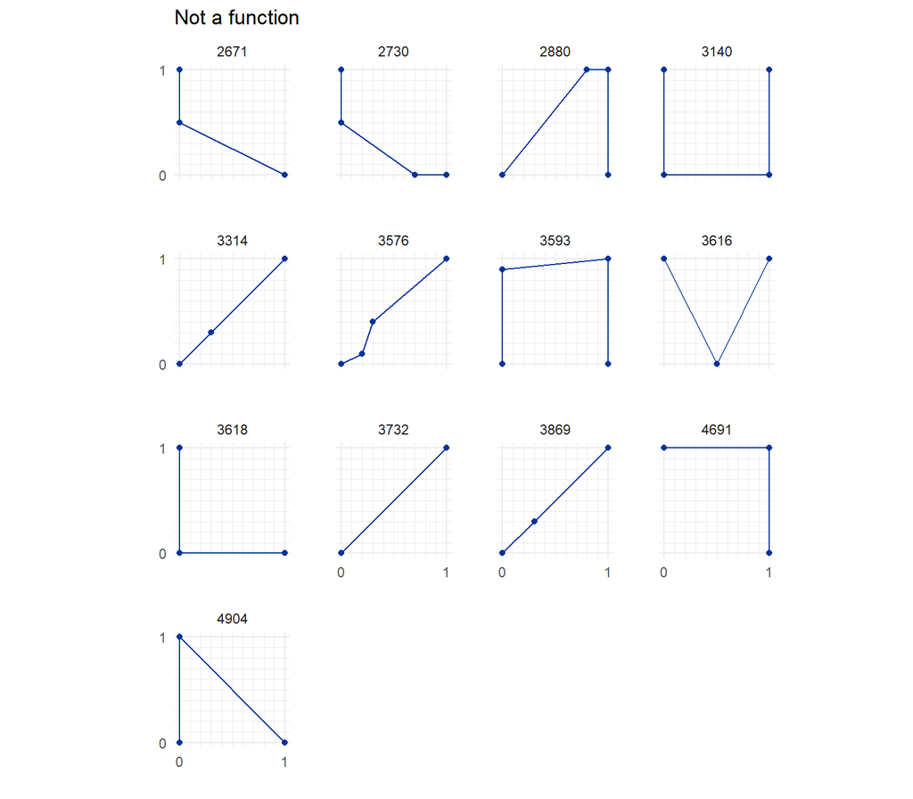

Note - response 3576 is being plotted incorrectly here: the student actually reversed the order of the middle two points ([[0.0,0.0],[0.3,0.4],[0.2,0.1],[1.0,1.0]]) so the graph would have looked like a “lightning bolt” shape to the student.

The remaining “not a function” responses are quite varied, failing to meet the required properties in different ways:

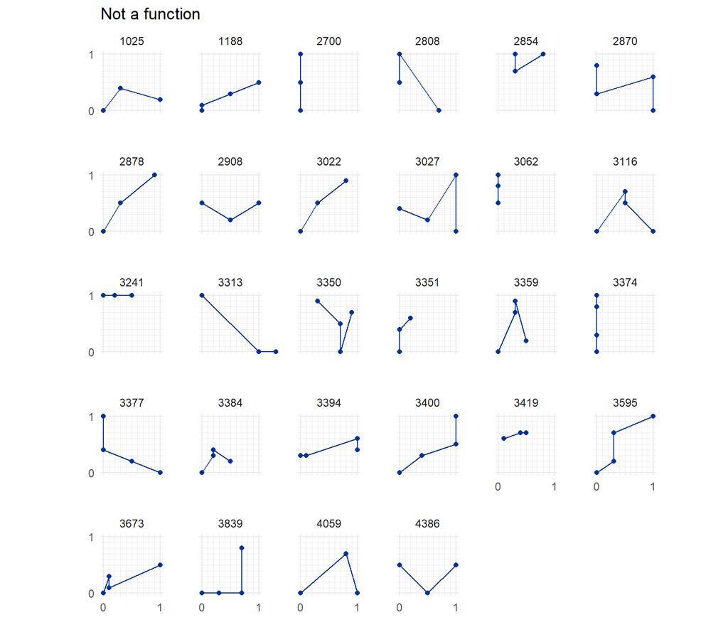

#### Partially correct

Many of the students gave examples that were not injective (as required) but also *not* surjective. Among them, a common pattern was to give a function with image $[0,\frac12]$:

[figure not shown]

Though many other students missed other parts of the image:

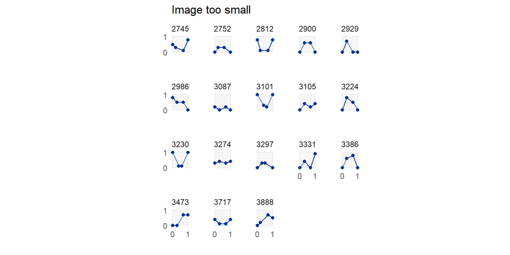

Another common error was to provide a surjective function, but one that was injective when it should not be:

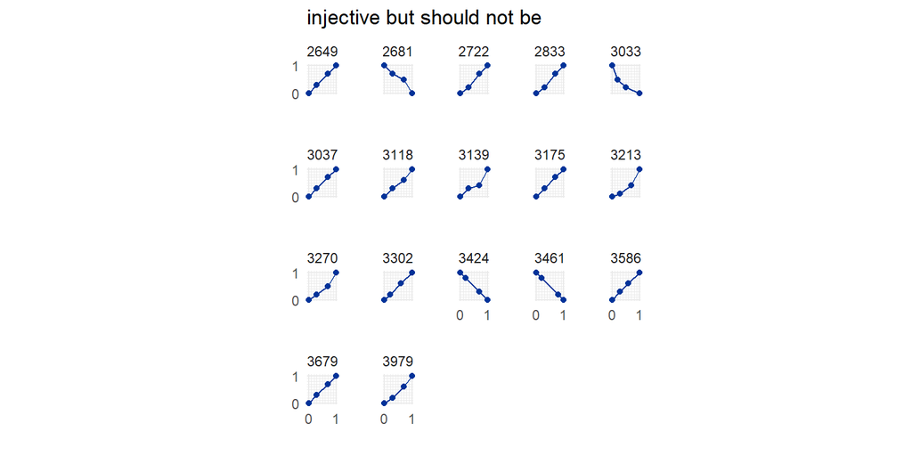

#### Incorrect

The remaining incorrect answers are quite diverse:

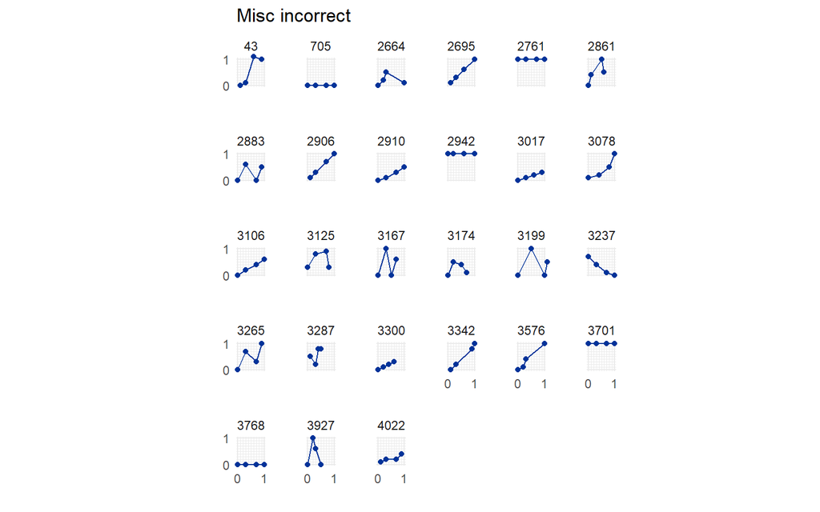

Several of those are horizontal lines.

### (d) injective, not surjective, and passes through $(0.2, 0.8)$ and $(0.5, 0.5)$

| score | example_type | nature_of_mistake | n |
| --- | --- | --- | --- |
| 1.0 | piecewise linear |  | 112 |
| 1.0 | piecewise linear | image goes beyond [0,1] | 1 |
| 0.9 | piecewise linear |  | 11 |
| 0.8 | piecewise linear |  | 3 |
| 0.8 | piecewise linear | No response | 2 |
| 0.6 | piecewise linear |  | 38 |
| 0.6 | piecewise linear | surjective but should not be | 24 |
| 0.5 | piecewise linear |  | 6 |
| 0.5 | piecewise linear | surjective but should not be | 5 |
| 0.4 | piecewise linear |  | 6 |
| 0.4 | piecewise linear | surjective but should not be | 1 |
| 0.2 | piecewise linear | surjective but should not be | 7 |
| 0.1 | piecewise linear | surjective but should not be | 4 |
| 0.0 | not a function | domain has gaps | 5 |
| 0.0 | not a function | domain is [0,1/2] | 4 |
| 0.0 | not a function | domain has gaps; image goes beyond [0,1] | 1 |
| 0.0 | not a function | domain has gaps; surjective but should not be | 1 |
| 0.0 | not a function | domain is [0,1/2]; surjective but should not be | 1 |
| 0.0 | not a function | surjective but should not be | 1 |
| 0.0 | piecewise linear | domain has gaps | 49 |
| 0.0 | piecewise linear | domain is [0,1/2] | 4 |
| 0.0 | piecewise linear |  | 1 |
| 0.0 | piecewise linear | domain exceeds [0,1] | 1 |
| 0.0 | piecewise linear | domain exceeds [0,1]; surjective but should not be | 1 |
| 0.0 | piecewise linear | domain has gaps; image goes beyond [0,1] | 1 |

#### Correct answers

Correct responses here are relatively constrained.

The most common correct answers fix the middle two points to the ones given in the task, and either have the first point below y=1 or the last point above y=0 (or both). We label these the “standard” answers.

A few students chose to use different locations for the middle two points, though still satisfying the conditions given in the task (labelled “nonstandard”).

| part_d_type | n |
| --- | --- |
| nonstandard | 5 |
| other | 1 |
| standard: both ends | 28 |
| standard: bottom end | 24 |
| standard: top end | 55 |

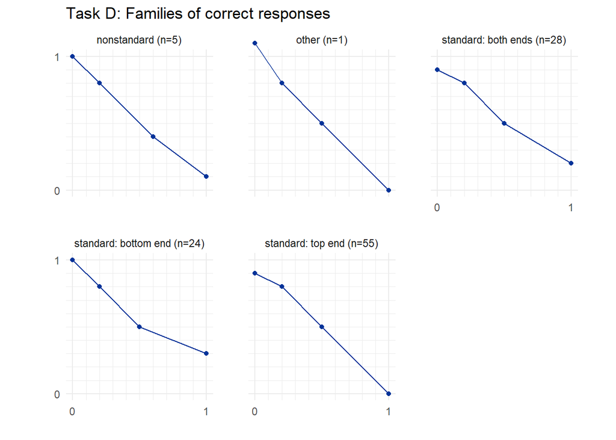

```
## Saving 18 x 12.7 cm image
```

The “other” example here is actually incorrect (by somehow having the first point at $(0, 1.1)$) and the STACK grading is not picking this up.

#### Partially correct

[figure not shown]

[figure not shown]

[figure not shown]

#### Incorrect

As before, several students included vertical segments or made two points coincide:

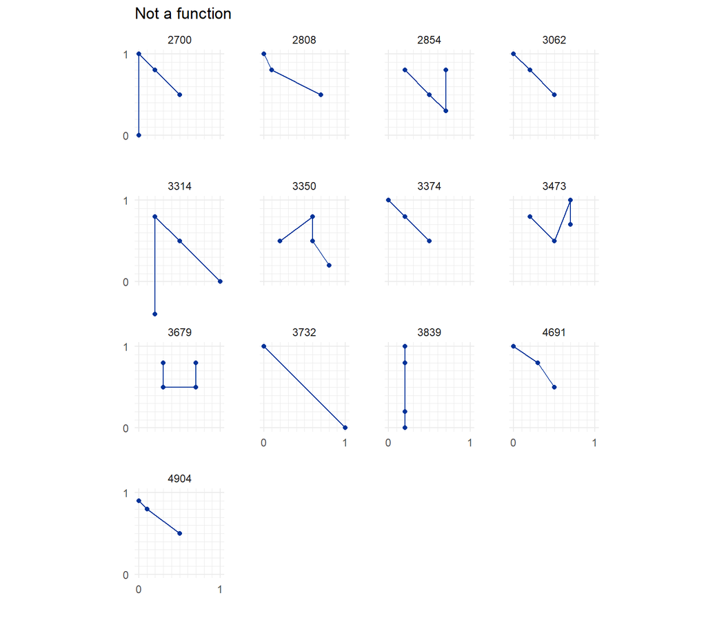

The most common class of incorrect responses had gaps in the domain:

[figure not shown]

The remaining incorrect answers are not very interesting:

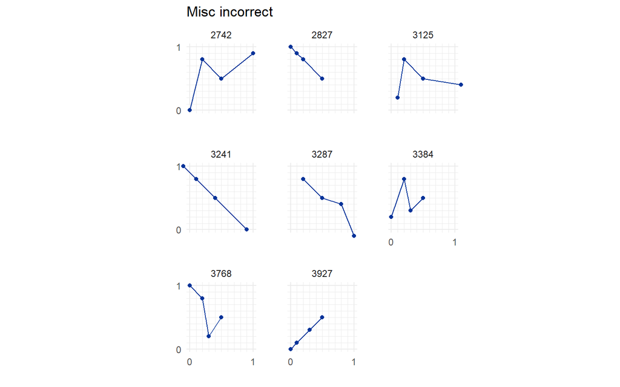